# Introduction to the first-order autoregressive model

Sophie W. Berkhout

5-10-2026

### Generating an AR(1) process

- `nt`: The total number of time points, with default $T = 30$.
- `c`: The intercept, with default $c = 3$.
- `phi`: The autoregressive parameter, with default $\phi = 0.3$.
- `resvar`: The residual (i.e., innovation) variance, with default $\sigma^2 = 1$.
- `burnin`: The total number of burnin iterations to use to let the process stabilize before saving the data (default = $500$).

### Plot time series

```r
plotTimeSeries <- function(df) {
  plot(df$t, df$y)
  abline(h = mean(df$y))
}
```

### Plot autocorrelation scatter plot

To create a scatter plot for the autocorrelation, you first have to create a lagged version of `y`. Use the following code chunk to compute the lagged variable and add this to the data frame `df` with the name `y_lag`.

Inspect the data frame to see whether the lagged variable is the same as the previous value of `y`.

```r
df$y_lag <- c(NA, df$y[-nrow(df)])
```

Now, you can create a function that plots a scatter plot that takes a data frame as input with columns `y`, and `y_lag`. Also add a regression line indicating the autoregressive effect.

```r
plotScatterAuto <- function(df) {
  plot(df$y_lag, df$y)
  abline(lm(y ~ y_lag, data = df))
}
```

```r
layout(matrix(c(1, 2), nrow = 1), widths = c(3, 2))
plotTimeSeries(df)
plotScatterAuto(df)
layout(1)
```

[output not shown]

### Simulating new data sets

You can run the following chunk over and over to simulate new data frames and visualize them each time. You can adjust the arguments in `simulateAR` to see how to process changes.

```r
df_new <- simulateAR(nt = 30, c = 3, phi = 0.3, resvar = 1)
df_new$y_lag <-  c(NA, df_new$y[-nrow(df_new)])
layout(matrix(c(1, 2), nrow = 1), widths = c(3, 2))
plotTimeSeries(df_new)
plotScatterAuto(df_new)
```

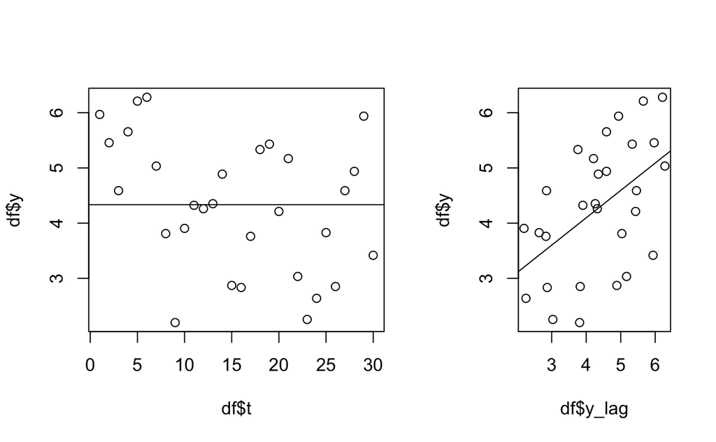

```r
layout(1)
```

### Fit an AR(1) model

You have already created a lagged version of `y` to make the autocorrelation scatter plot. You can now use the same data frame to fit an AR(1) model using linear regression. Use `y` as the dependent variable and `y_lag` as the independent variable.

```r
# your code to fit a linear regression model
mod1 <- lm(y ~ y_lag, df)
mod1
```

```
Call:
lm(formula = y ~ y_lag, data = df)

Coefficients:
(Intercept)        y_lag
     2.4796       0.3923
```

Are the parameters (intercept and autoregression) recovered well? You can simulate a data set with a larger sample size to confirm. You will have to create a new lagged column in that case.

Compute the mean from the estimated parameters (recall that $\mu = \frac{c}{1 - \phi}$).

```r
coef(mod1)[1] / (1 - coef(mod1)[2])
```

```
(Intercept)
   4.080131
```

### Alternative AR(1) model

Now run the following chunk. What happens to the parameter values?

```r
y_mean <- mean(df$y)
cat(paste("The mean of y is: ", round(y_mean, 3)))
```

```
The mean of y is:  4.007
```

```r
df$y_lag_c <- df$y_lag - y_mean
mod2 <- lm(y ~ y_lag_c, df)
mod2
```

```
Call:
lm(formula = y ~ y_lag_c, data = df)

Coefficients:
(Intercept)      y_lag_c
     4.0516       0.3923
```